# SF Vignette - natural variables / eigen-analysis

Glen Pridham 2023 Rutengroup

Tutorial on using sf.R. SF: stochastic finite model.

Purpose: demonstrate how to perform eigen analysis (i.e. find the natural aging variables).

Before we start, it is important to note that the natural aging variables cannot be estimated for an individual / timepoint with missing data (practically impossible). Hence you must impute if you want to know natural aging variable scores for people with missing data.

The procedure goes as follows: 1. Estimate a model. You need the network, W. 2. Eigen-decompose W, eigen(W). 3. The transformation matrix to natural variables is the inverse of the eigen-matrix, solve(eigen(W)[[2]]) 4. Transform the input data. 5. You’ll probably want to look at the eigenvalues, eigen(W)[[1]], to determine the relative stability of each natural variable. Usually the least stable (most positive) are the most important.

Step 1 uses FitSF or BootSF whereas steps 2-4 are performed automatically by the function Natural.SF.

We demonstrate the process using artificial test data.

```r
outputDir = ""  #enter the file location for the SF (github) files here
source(sprintf("%s/sf.R",outputDir))
```

```r
y  = readRDS(sprintf("%s/test_y_array.rds",outputDir))
x  = readRDS(sprintf("%s/test_x_array.rds",outputDir))
#dt = readRDS(sprintf("%s/test_dt.csv",outputDir)) #we can load or make our own dt
dt = x[,"age",-1] - x[,"age",-dim(x)[3]]
print(dim(x))
```

```
[1] 1000    2   20
```

```r
print(dim(y))
```

```
[1] 1000    5   20
```

To fit we use the master function FitSF

```r
sf = FitSF(y=y,x=x,dt=dt)
```

```
[1] "Imputing age in column age"
[1] "Age imputation correct?"
[1] TRUE
[1] "Iterations selected: 5.0"
[1] "Noise precision matrix has been supplied..."
[1] "NAs to replace: 0, total NAs: 0 (diff: 0)"
[1] "NAs to replace: 0, NAs replaced by initial imputation: 0 (imputed: NaN%)"
[1] "initial imputation options:"
list()
[1] "NAs after iterating:"
[1] 0
```

Now let’s look at the natural variables.

By default we only consider the real part. The imaginary part may or may not be 0.

```r
n = Natural.SF(sf,realOnly=T)
print(names(n))
```

```
 [1] "z"       "zsd"     "eig"     "P"       "Pinv"    "W"       "lambda"  "Q"       "dW"      "dlambda"
```

We sort the natural variables by their eigenvalue strengths,

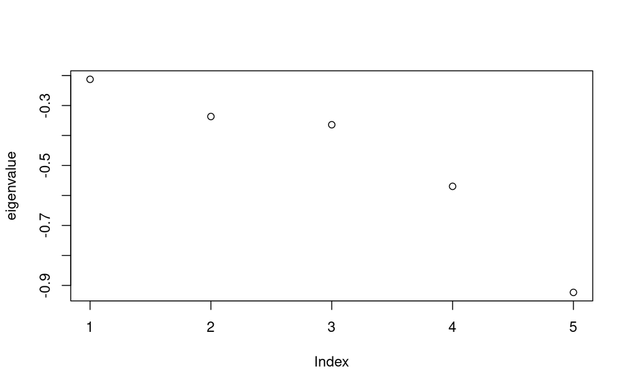

```r
plot(n$eig[[1]],ylab="eigenvalue")
```

The first eigenvalue should be the most important since it has the lowest resilience, although we typically look for ‘elbows’ so 1-3 could all be important.

So what do the natural variables (z) look like? They look just like the input data!

```r
print("input data:")
```

```
[1] "input data:"
```

```r
print(str(y)) #input data
```

```
 num [1:1000, 1:5, 1:20] -8.29 3.58 -0.92 18.85 -2.78 ...
 - attr(*, "dimnames")=List of 3
  ..$ : NULL
  ..$ : chr [1:5] "y01" "y02" "y03" "y04" ...
  ..$ : NULL
NULL
```

```r
print("natural variables:")
```

```
[1] "natural variables:"
```

```r
print(str(n$z)) #natural variables
```

```
 num [1:1000, 1:5, 1:20] -2.017 -2.183 0.109 -9.394 21.61 ...
 - attr(*, "dimnames")=List of 3
  ..$ : NULL
  ..$ : chr [1:5] "z1" "z2" "z3" "z4" ...
  ..$ : NULL
NULL
```

The natural variables behave just like the original variables and can be used in place of them.

Well what goes into each natural variable? Pinv transforms from y to z, hence the rows of Pinv determine what’s in each z,

```r
print("z1 contents (Pinv):")
```

```
[1] "z1 contents (Pinv):"
```

```r
print(n$Pinv[1,])
```

```
       y01        y02        y03        y04        y05
-0.1276466  0.6001554  0.1913650 -0.1520255 -0.7521265
```

```r
print("z1 correlations:")
```

```
[1] "z1 correlations:"
```

```r
rho = numeric()
for (j in 1:ncol(y)) rho[j] = cor(c(n$z[,1,]),c(y[,j,]),use='pairwise.complete')
print(rho)
```

```
[1] -0.1146016  0.6761209  0.2897053 -0.2418227 -0.8189437
```

```r
plot(n$Pinv[1,],ylab="association strength",ylim=c(-1,1))
points(rho,col=2,pch=2)
```

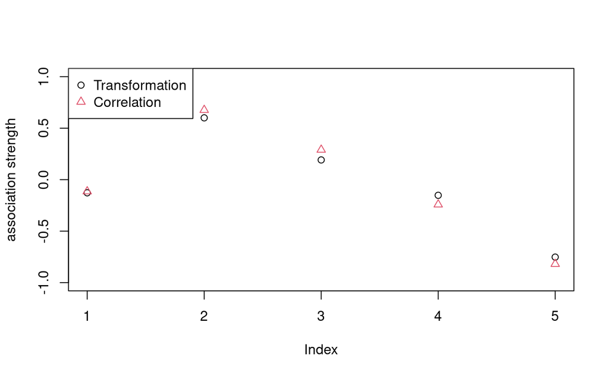

```r
legend("topleft",c("Transformation","Correlation"),pch=1:2,col=1:2)
```

Observe that the correlation between z1 and each input variable is roughly equal to the transformation Pinv[1,]. z1 is simply a linear combination of the ys.

# The original variables

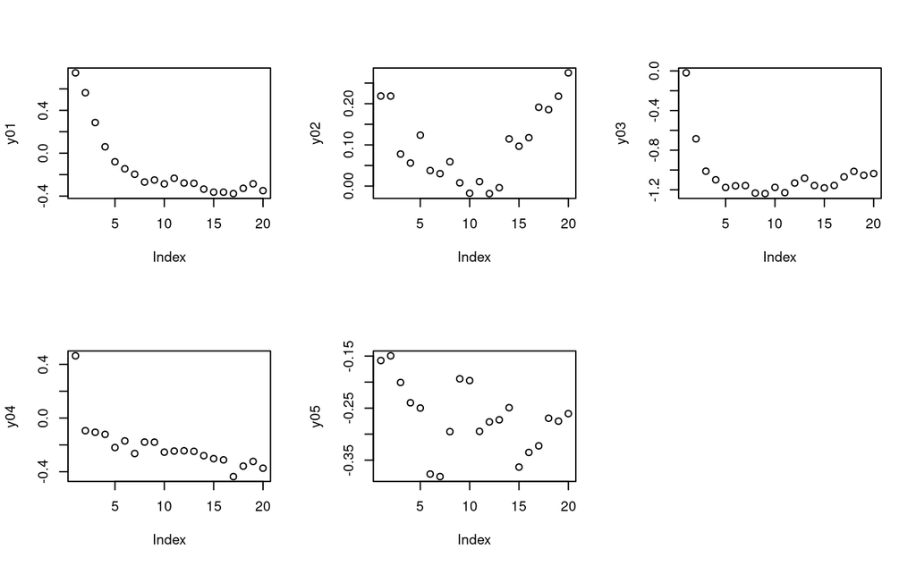

```r
par(mfrow=c(2,3)) #for multiple plots on same canvas
for (i in 1:ncol(y)) plot(apply(y[,i,],2,mean),ylab=colnames(y)[i])
```

# The natural variables (linear combinations of the input y)

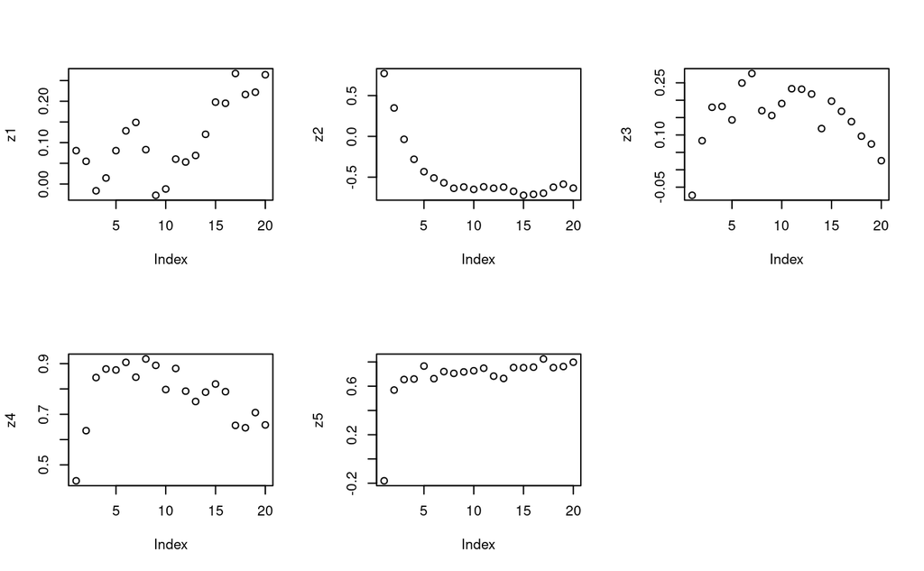

```r
par(mfrow=c(2,3)) #for multiple plots on same canvas
for (i in 1:ncol(n$z)) plot(apply(n$z[,i,],2,mean),ylab=colnames(n$z)[i])
```

What do I do with the natural variables now? Whatever you want. z1 tends to be a good predictor of adverse outcome e.g. survival.